# Gapminder

2026-03-04

#Libraries

```r
library(tidyverse)#includes ggplot2, dplyr, tidyr, readr
library(janitor)#cleaning column names
library(naniar)#missing data visualization
```

```r
getwd() #checking the work directory (helps debug file path issues)
```

```
## [1] "/Users/switters/Desktop/BIS15L_W2026_Group9/Gapminder"
```

#Data set and cleaning (Mia)

```r
#loading all of the data sets
gapminder_life_expectancy<- read.csv("data/Life_expectancy.csv")
```

```r
getwd
```

```
## function ()
## .Internal(getwd())
## <bytecode: 0x11131b4a8>
## <environment: namespace:base>
```

```r
co2_emissions<-read_csv("data/co2_pcap_cons.csv")
Pop<-read_csv("Data/pop.csv")
Hiv_death<-read_csv("Data/hiv_death.csv")
Child_death<- read.csv("Data/number_of_child_deaths.csv")
```

```r
gdp<- read_csv("Data/gdp.csv")
lung_cancerF<- read_csv("Data/lung_cancer_f.csv")
lung_cancerM<- read_csv("Data/lung_cancer_m.csv")
```

#pivoting and fixing year + other problems (mia)

```r
#converts wider to long formart (years become rows instead of collumns)
gapminder_life_expectancy<- gapminder_life_expectancy %>%
  pivot_longer(-c(name,geo),
               names_to = "year",
               values_to = "life_expectancy") %>%
  mutate(year= str_remove(year, "X"))#removes prefix x from year
```

```r
#repeat the pivoting for all datasets
Child_death<-Child_death %>%
pivot_longer(-c(name,geo),
               names_to = "year",
               values_to = "child_death") %>%
  mutate(year= str_remove(year, "X"))
```

```r
co2_emissions<- co2_emissions %>%
  pivot_longer(-c(geo,name),
               names_to = "year",
              values_to = "Co2_emissions")
```

```r
pop<- Pop %>%
  pivot_longer(-c(geo,name),
               names_to = "year",
              values_to = "population")
```

```r
hiv_death<- Hiv_death %>%
  pivot_longer(-c(geo,name),
               names_to = "year",
               values_to = "hiv_deaths")
```

```r
gdp<- gdp %>%
  pivot_longer(-c(geo,name),
               names_to = "year",
               values_to = "gdp")
```

```r
 lung_cancerF<-lung_cancerF %>%
  pivot_longer(-c(geo,name),
               names_to = "year",
               values_to = "lung_cancerf")
```

```r
 lung_cancerM<-lung_cancerM %>%
  pivot_longer(-c(geo,name),
               names_to = "year",
               values_to = "lung_cancerm")
```

#Joining data tables (mia)

```r
#full joins of each loaded dartaser (keeps all data even if missing)
gp<-full_join(Child_death, gapminder_life_expectancy, by= c("name", "geo","year"))
```

```r
gp2<-full_join(gp, co2_emissions, by= c("name", "geo","year"))
```

```r
gp3<-full_join(gp2,pop, by= c("name", "geo","year"))
```

```r
gp4<-full_join(gp3,hiv_death, by= c("name", "geo", "year") )
```

```r
#gp5<- full_join(gp4, kcals_per_day, by = c("name","geo","year"))
```

```r
gp5<- full_join(gp4, gdp, by = c("name", "year","geo") )
```

```r
gp6<- full_join(gp5,lung_cancerF, by = c("name", "year","geo") )
```

```r
#the final join to have every dataset together int he tables
gapminder<- full_join(gp6,lung_cancerM, by = c("name", "year","geo") )
```

#FILTERING THE YEARS (mia)

```r
gapminder<- gapminder %>%
  filter(year>= "1915", year<="2022") #filtering the dates to have a more manageable set to work with
```

#seperating each country into a continent (joanna)

```r
#assigning continent manually
gapminder <- gapminder %>%
  mutate(continent = case_when(
    name %in% c("Argentina", "Bolivia", "Brazil", "Chile", "Colombia", "Ecuador", "Guyana", "Paraguay", "Peru", "Suriname", "Uruguay", "Venezuela") ~ "South America",

    name %in% c("Australia", "Papua New Guinea", "New Zealand", "Fiji", "Solomon Islands", "Vanuatu", "Samoa", "Kiribati", "Micronesia", "Tonga", "Marshall Islands", "Palau", "Nauru", "Tuvalu", "Micronesia, Fed. Sts.") ~ "Oceania",

    name %in% c("USA", "Mexico", "Canada", "Guatemala", "Haiti", "Dominican Republic", "Honduras", "Cuba", "Nicaragua", "El Salvador", "Costa Rica", "Panama", "Jamaica", "Trinidad and Tobago", "Belize", "Bahamas", "Barbados", "St. Lucia", "Grenada", "St. Vincent and the Grenadines", "Antigua and Barbuda", "Dominica", "St. Kitts and Nevis") ~ "North America",

    name %in% c("Germany", "UK", "France", "Italy","Spain", "   Ukraine", "Poland", "Romania", "Netherlands", "Belgium", "Sweden", "Czech Republic", "  Portugal", "Greece", "Hungary","Austria", " Switzerland", "Belarus", "Bulgaria", "Serbia", "Denmark", "Norway", "Finland", "Finland", "Ireland", "Croatia", "   Bosnia and Herzegovina", "Moldova", "Lithuania", "Albania", "Slovenia", "Latvia", "North Macedonia", "Cyprus", "Estonia", "Luxembourg", "Montenegro", "Malta", "Iceland", "Andorra", "Liechtenstein", "Monaco", "San Marino", "Vatican City", "Bosnia and Herzegovina", "Switzerland", "Portugal", "Slovak Republic", "Ukraine", "Holy See") ~ "Europe",

    name %in% c("Russia", "Azerbaijan") ~ "Eurasia",

    name %in% c("India", "China", "Indonesia", "Pakistan", "Bangladesh", "Japan", "Philippines", "Vietnam", "Iran", "Turkey", "Thailand", "Myanmar", "South Korea", "Iraq", "Afghanistan", "Yemen", "Uzbekistan", "Malaysia", "Saudi Arabia", "Nepal", "North Korea", "Syria", "Sri Lanka", "Kazakhstan", " Cambodia", "Jordan", "UAE", "Tajikistan", " Azerbaijan", "Israel", "Laos", "Turkmenistan", "Kyrgyzstan", "Singapore", "Lebanon", "Palestine", "Oman", "Kuwait", "Georgia", "    Mongolia", "Qatar", "Armenia", "Bahrain", "Timor-Leste", "Bhutan", "    Maldives", "Brunei", "Kyrgyz Republic", "Cambodia", "Lao", "Maldives", "Mongolia") ~ "Asia",

    name %in% c("Nigeria", "Ethiopia", "Egypt", "Congo, Dem. Rep.", "Tanzania", "South Africa", "Kenya", "Sudan", "Uganda", "Algeria", "Angola", "Morocco", "Mozambique", "Ghana", "Madagascar", "Cameroon", "Niger", "Mali", "Burkina Faso", "Malawi", "Zambia", "Chad", "Somalia", "Senegal", "Zimbabwe", "Guinea", "Benin", "Rwanda", "Burundi", "South Sudan", "Tunisia", "Togo", "Sierra Leone", "Libya", "Congo, Rep.", "Liberia", "Central African Republic", "Mauritania", "Eritrea", "Namibia", "Gambia", "Gabon", "Botswana", "Lesotho", "Guinea-Bissau", "Equatorial Guinea", "Eswatini", "  Mauritius", "Djibouti", "Comoros", "Cape Verde", "Sao Tome and Principe", "Seychelles", "Cote d'Ivoire", "Mauritius") ~ "Africa"
  ))
```

#add coordinates for mapping (Joanna)

```r
#assigning approximate continent center coordinates
gapminder <- gapminder %>%
  mutate(longitude = case_when(
    continent %in% "Africa" ~ "19.5687",
    continent %in% "Asia" ~ "87.3311",
    continent %in% "Eurasia" ~ "70.5158",
    continent %in% "Europe" ~ "25.3200",
    continent %in% "North America" ~ "-100.1667",
    continent %in% "Oceania" ~ "133.2102",
    continent %in% "South America" ~ "-56.1015"
  ))
```

```r
gapminder <- gapminder %>%
  mutate(latitude = case_when(
    continent %in% "Africa" ~ "6.614",
    continent %in% "Asia" ~ "48.35",
    continent %in% "Eurasia" ~ "49.5786",
    continent %in% "Europe" ~ "54.9067",
    continent %in% "North America" ~ "48.1667",
    continent %in% "Oceania" ~ "-25.9458",
    continent %in% "South America" ~ "-15.5991"
  ))
```

```r
gapminder <- gapminder %>%
  mutate(longitude = as.numeric(longitude),
         latitude = as.numeric(latitude))
```

#final data set

```r
gapminder
```

```
## # A tibble: 21,060 × 14
##    geo   name        year  child_death life_expectancy Co2_emissions population
##    <chr> <chr>       <chr>       <int>           <dbl>         <dbl>      <dbl>
##  1 afg   Afghanistan 1915       145399           37.4          0.001    7947691
##  2 afg   Afghanistan 1916       156049           37.6          0.001    8550978
##  3 afg   Afghanistan 1917       167480           37.7          0.001    9200053
##  4 afg   Afghanistan 1918       179890            9.88         0.001    9905878
##  5 afg   Afghanistan 1919       187873           38            0.001   10370737
##  6 afg   Afghanistan 1920       191411           38.1          0.001   10591626
##  7 afg   Afghanistan 1921       190453           38.3          0.001   10564504
##  8 afg   Afghanistan 1922       184946           38.4          0.001   10284244
##  9 afg   Afghanistan 1923       174810           38.6          0.001    9744601
## 10 afg   Afghanistan 1924       165727           38.7          0.001    9233274
## # ℹ 21,050 more rows
## # ℹ 7 more variables: hiv_deaths <dbl>, gdp <dbl>, lung_cancerf <dbl>,
## #   lung_cancerm <dbl>, continent <chr>, longitude <dbl>, latitude <dbl>
```

```r
#dataset written as csv in order to open easier in shiny apps
write.csv(gapminder, file="gapminder.csv", row.names=FALSE)
```

```r
gapminder<-read_csv("gapminder.csv")
#gapminder  (checking the dataset looks good)
```

#visualiding missing values (mia)

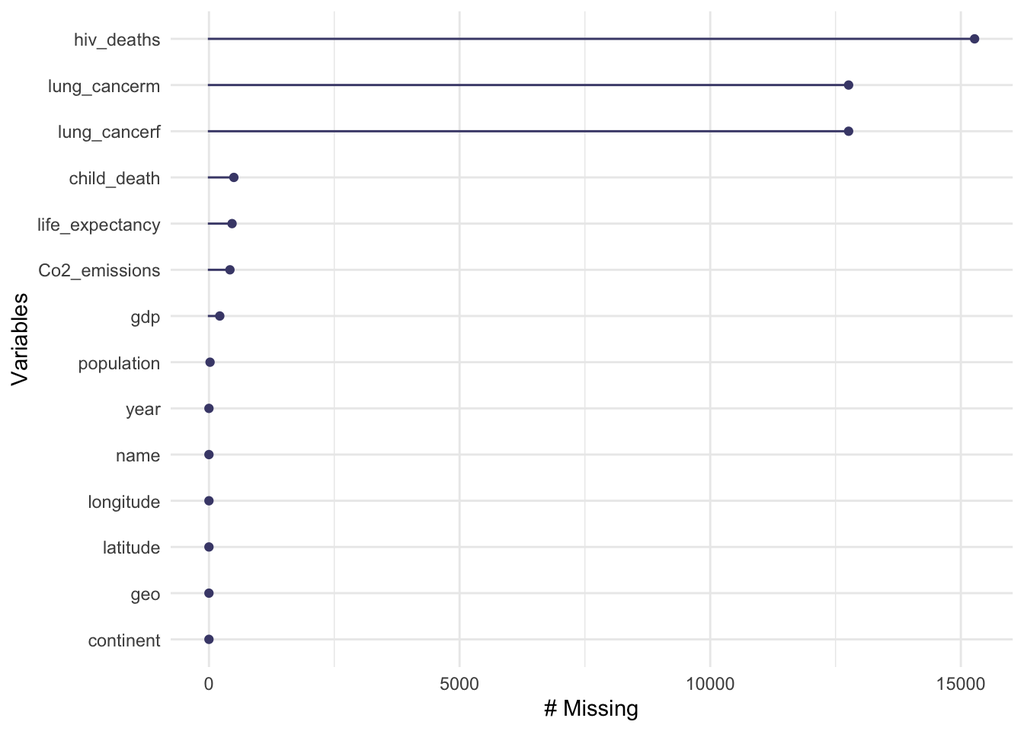

```r
gg_miss_var(gapminder)
```

#summary of missing data (mia)

```r
gapminder %>%
  miss_var_summary(order=T)
```

```
## # A tibble: 14 × 3
##    variable        n_miss pct_miss
##    <chr>            <int>    <num>
##  1 hiv_deaths       15274   72.5
##  2 lung_cancerf     12761   60.6
##  3 lung_cancerm     12761   60.6
##  4 child_death        497    2.36
##  5 life_expectancy    461    2.19
##  6 Co2_emissions      419    1.99
##  7 gdp                216    1.03
##  8 population          22    0.104
##  9 geo                  0    0
## 10 name                 0    0
## 11 year                 0    0
## 12 continent            0    0
## 13 longitude            0    0
## 14 latitude             0    0
```

#Analysis examples

is there correlation between the top and bottom co2 emissions and lung cancer, does it look as though there is enough data to see?

#top 3 highest co2 emissions per capita (mia)

```r
gapminder %>%
  select(name, Co2_emissions, year) %>%
  pivot_wider(names_from = "name",
              values_from = "Co2_emissions")
```

```
## # A tibble: 108 × 196
##     year Afghanistan Angola Albania Andorra   UAE Argentina Armenia
##    <dbl>       <dbl>  <dbl>   <dbl>   <dbl> <dbl>     <dbl>   <dbl>
##  1  1915       0.001  0.018   0.006    2.29 0.115     0.897   0.183
##  2  1916       0.001  0.018   0.006    2.22 0.118     0.628   0.194
##  3  1917       0.001  0.019   0.006    2.32 0.116     0.274   0.177
##  4  1918       0.001  0.019   0.006    2.30 0.119     0.302   0.07
##  5  1919       0.001  0.021   0.006    2.21 0.117     0.434   0.059
##  6  1920       0.001  0.021   0.004    2.06 0.119     0.668   0.053
##  7  1921       0.001  0.022   0.005    2.21 0.127     0.611   0.057
##  8  1922       0.001  0.022   0.005    1.98 0.124     0.782   0.069
##  9  1923       0.001  0.022   0.005    2.30 0.125     0.878   0.076
## 10  1924       0.001  0.023   0.005    2.23 0.139     1.11    0.09
## # ℹ 98 more rows
## # ℹ 188 more variables: `Antigua and Barbuda` <dbl>, Australia <dbl>,
## #   Austria <dbl>, Azerbaijan <dbl>, Burundi <dbl>, Belgium <dbl>, Benin <dbl>,
## #   `Burkina Faso` <dbl>, Bangladesh <dbl>, Bulgaria <dbl>, Bahrain <dbl>,
## #   Bahamas <dbl>, `Bosnia and Herzegovina` <dbl>, Belarus <dbl>, Belize <dbl>,
## #   Bolivia <dbl>, Brazil <dbl>, Barbados <dbl>, Brunei <dbl>, Bhutan <dbl>,
## #   Botswana <dbl>, `Central African Republic` <dbl>, Canada <dbl>, …
```

```r
gapminder %>%
  filter(year>= "1980", year<="2022") %>%
  group_by(name) %>%
  summarize(avgco2=mean(Co2_emissions)) %>%
  arrange(desc(avgco2)) %>%
  slice_head(n=3)
```

```
## # A tibble: 3 × 2
##   name      avgco2
##   <chr>      <dbl>
## 1 Qatar       31.7
## 2 Singapore   26.9
## 3 UAE         26.0
```

#bottom 3 lowest co2 emissions (mia)

```r
gapminder %>%
  filter(name != c("Holy See", "Monaco", "San Marino"), year>= "1980", year<="2022") %>%
  group_by(name) %>%
  summarize(avgco2=mean(Co2_emissions, na.rm=T)) %>%
  arrange(desc(avgco2)) %>%
slice_tail(n=6)
```

```
## # A tibble: 6 × 2
##   name               avgco2
##   <chr>               <dbl>
## 1 Chad               0.0605
## 2 Congo, Dem. Rep.   0.0588
## 3 Burundi            0.0394
## 4 Holy See         NaN
## 5 Monaco           NaN
## 6 San Marino       NaN
```

```r
gapminder %>%
   filter(name ==c("Chad", "Congo, Dem. Rep.", "Burundi"), year>= "1980", year<="2022") %>%
  group_by(name) %>%
  summarize(mlungavg= mean(lung_cancerm), flungavg=mean(lung_cancerf))
```

```
## # A tibble: 3 × 3
##   name             mlungavg flungavg
##   <chr>               <dbl>    <dbl>
## 1 Burundi              89.9     35.5
## 2 Chad                159.      50.7
## 3 Congo, Dem. Rep.    863.     492.
```

```r
gapminder %>%
  select(name, year, Co2_emissions) %>%
  filter(year >= "1980", year<="2022") %>%
pivot_wider(names_from = "year",
            values_from = Co2_emissions)
```

```
## # A tibble: 195 × 44
##    name    `1980` `1981` `1982` `1983` `1984` `1985` `1986` `1987` `1988` `1989`
##    <chr>    <dbl>  <dbl>  <dbl>  <dbl>  <dbl>  <dbl>  <dbl>  <dbl>  <dbl>  <dbl>
##  1 Afghan…  0.132   0.15  0.163  0.201  0.231  0.294  0.267  0.269  0.246  0.233
##  2 Angola   0.64    0.61  0.518  0.55   0.519  0.47   0.449  0.542  0.457  0.43
##  3 Albania  0.842   1.17  1.63   1.59   1.63   1.64   1.61   1.61   1.45   1.39
##  4 Andorra  7.10    7.06  6.86   6.70   6.73   6.78   7.14   7.33   7.35   7.44
##  5 UAE     10.8    15.8  17.1   17.4   15.8   18.7   21.9   25.1   26.5   27.6
##  6 Argent…  3.96    3.66  3.38   3.37   3.37   3.36   3.12   3.18   3.45   3.59
##  7 Armenia  1.78    1.72  1.67   1.67   1.68   1.67   1.77   1.74   1.71   1.73
##  8 Antigu…  2.31    1.72  4.75   1.36   2.37   4.04   4.04   4.46   4.63   4.61
##  9 Austra… 12.5    12.9  13.3   13.3   12.6   13.1   13.1   12.9   13.5   13.5
## 10 Austria 10.5    11.3  12.2   11.7   11.3   11.8   11.8   11.7   12.4   11.4
## # ℹ 185 more rows
## # ℹ 33 more variables: `1990` <dbl>, `1991` <dbl>, `1992` <dbl>, `1993` <dbl>,
## #   `1994` <dbl>, `1995` <dbl>, `1996` <dbl>, `1997` <dbl>, `1998` <dbl>,
## #   `1999` <dbl>, `2000` <dbl>, `2001` <dbl>, `2002` <dbl>, `2003` <dbl>,
## #   `2004` <dbl>, `2005` <dbl>, `2006` <dbl>, `2007` <dbl>, `2008` <dbl>,
## #   `2009` <dbl>, `2010` <dbl>, `2011` <dbl>, `2012` <dbl>, `2013` <dbl>,
## #   `2014` <dbl>, `2015` <dbl>, `2016` <dbl>, `2017` <dbl>, `2018` <dbl>, …
```

#add total lung cancer (mia)

```r
gapminder<- gapminder %>%
  mutate(lungcancertot=lung_cancerf+lung_cancerm)
```

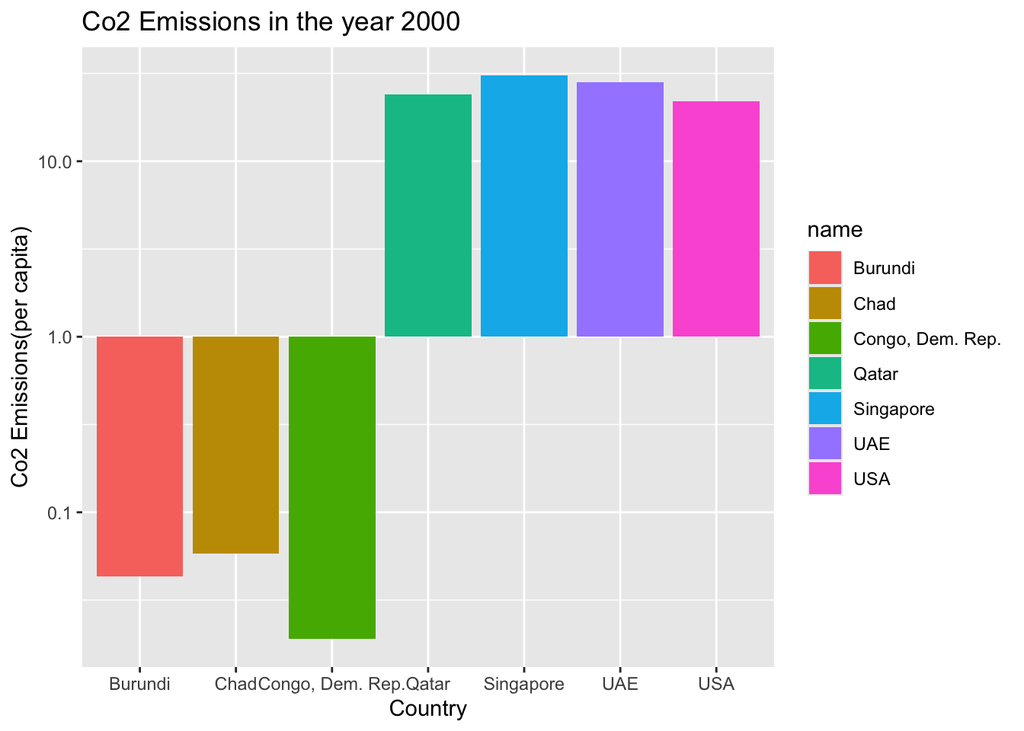

```r
gapminder %>%
  select(name, year, Co2_emissions, lung_cancerf, lung_cancerm) %>%
  filter(name== "Qatar"|
         name == "Singapore"|
         name == "USA"|
           name== "Chad"|
           name== "Burundi"|
           name== "Congo, Dem. Rep."|
         name=="UAE",
         year== "2000") %>%
   ggplot(aes(x=name, y=Co2_emissions, fill = name ))+
  geom_col()+
  scale_y_log10()+
  labs(title = "Co2 Emissions in the year 2000",
       x="Country",
       y= "Co2 Emissions(per capita)")
```

#lung cancer by sex (mia)

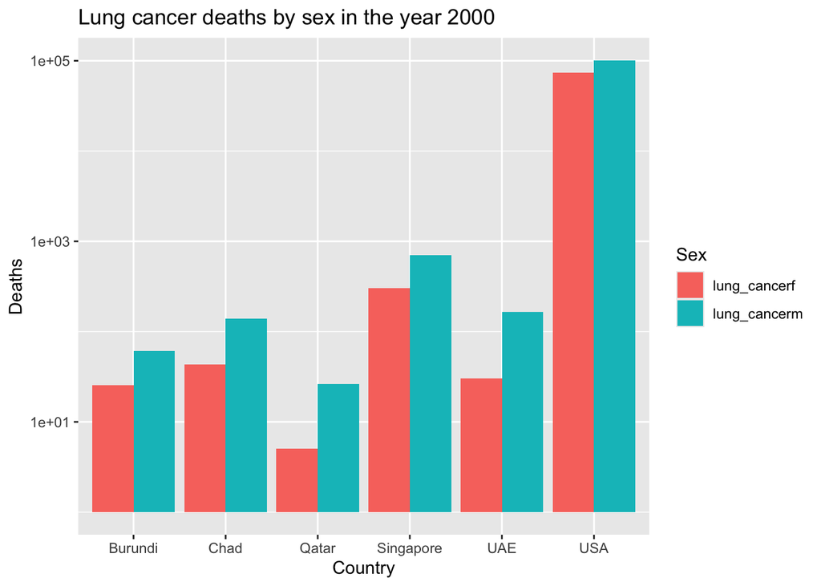

```r
gapminder %>%
  select(name, year, Co2_emissions, lungcancertot, lung_cancerf, lung_cancerm) %>%
  filter(name== "Qatar"|
         name == "Singapore"|
         name == "USA"|
           name== "Chad"|
           name== "Burundi"|
         name=="UAE",
         year =="2000") %>%  #qatar, singapore, usa, chad, burundi
   pivot_longer(cols = c(lung_cancerf, lung_cancerm),
               names_to = "sex",
               values_to = "deaths")  %>%
  ggplot(aes(x=name, y= deaths, fill = sex ))+
  geom_col(position= "dodge")+
  scale_y_log10()+
  labs(title = "Lung cancer deaths by sex in the year 2000",
       x="Country",
       y= "Deaths",
       fill= "Sex")
```

trying to see correlation between gdp and the amount of child deaths, to later see if gdp and population have a similar or different relationship.

#gdp vs child deaths (mia)

```r
gapminder %>%
  distinct(name) %>%
  arrange(name)
```

```
## # A tibble: 195 × 1
##    name
##    <chr>
##  1 Afghanistan
##  2 Albania
##  3 Algeria
##  4 Andorra
##  5 Angola
##  6 Antigua and Barbuda
##  7 Argentina
##  8 Armenia
##  9 Australia
## 10 Austria
## # ℹ 185 more rows
```

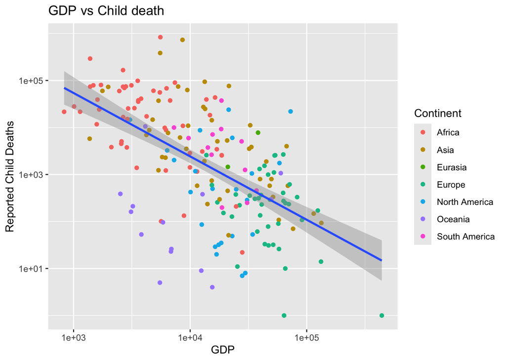

```r
gapminder %>%
  filter(year== "2022") %>%
  ggplot(aes(x= gdp, y= child_death ))+
    geom_point(aes(colour= continent))+
  scale_y_log10()+
  scale_x_log10()+
    geom_smooth(method = lm, rm=T, legend= NULL)+
  labs(title = "GDP vs Child death",
       x= "GDP",
       y= "Reported Child Deaths",
       color = "Continent")
```

Here is the work we did to see if a population size might have an increase or a larger amount when gdp is higher, because child death is lower

#creating smaller dataset (mia)

```r
#creating a new data set in order to quickly plot the graphs for population vs gdp of the top 10 countries
popgraph1<-gapminder %>%
  select(year, name, gdp, population) %>%
  filter(name!= "Monaco",
         year== "2022") %>%
  arrange(desc(gdp)) %>%
  slice_head(n=5)
```

```r
#second half of the smaller dataset
popgraph2<-gapminder %>%
  select(year, name, gdp, population) %>%
  filter(name!= "Monaco"&
         name!= "Liechtenstein"&
         name!= "Holy See",
         year== "2022") %>%
  arrange(desc(gdp)) %>%
  slice_tail(n=5)
```

```r
#joining the two datasets in order to have one graph fro the poulations
popgraph<-full_join(popgraph1, popgraph2, by= c("year", "name", "gdp", "population"))
```

#popualtion graph (mia)

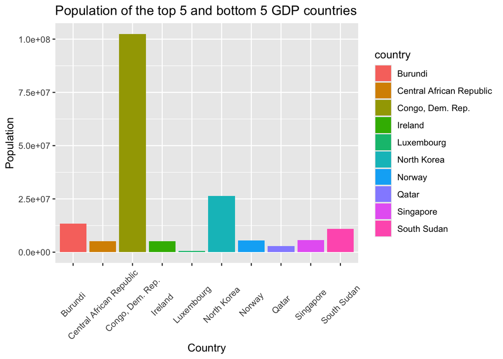

```r
popgraph %>%
  ggplot(aes(x=name, y= population))+
  geom_col(aes(fill = name))+
    theme(axis.text.x= element_text(angle = 45, vjust= 0.5))+
  labs(title = "Population of the top 5 and bottom 5 GDP countries",
       x="Country",
       y="Population",
       fill= "country")
```

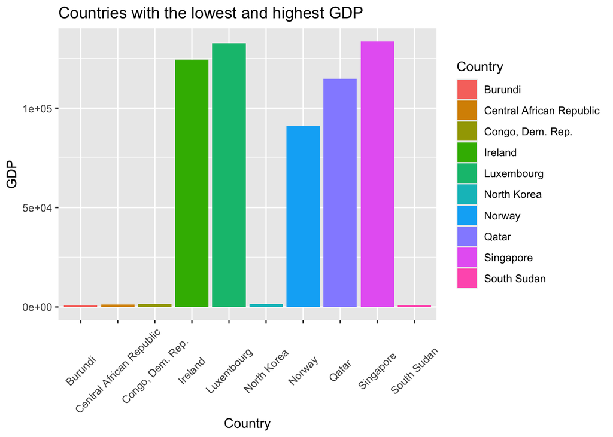

```r
popgraph %>%
  ggplot(aes(x=name, y= gdp))+
  geom_col(aes(fill = name))+
  theme(axis.text.x= element_text(angle = 45, vjust = 0.5))+
  labs(title = "Countries with the lowest and highest GDP",
       x="Country",
       y= "GDP",
       fill= "Country")
```

```r
gapminder %>%
  group_by (continent) %>%
  summarize(mean(life_expectancy, na.rm = T))
```

```
## # A tibble: 7 × 2
##   continent     `mean(life_expectancy, na.rm = T)`
##   <chr>                                      <dbl>
## 1 Africa                                      48.8
## 2 Asia                                        54.6
## 3 Eurasia                                     54.6
## 4 Europe                                      66.4
## 5 North America                               60.2
## 6 Oceania                                     57.2
## 7 South America                               58.2
```